# Predicting Voter Behavior

Carter Taffe, Parsa Zadeh

11/29/2022

## Election Data Properties

```
## [1] "Dimenstions of election data"
```

```
## [1] 32177     5
```

```
## [1] "Number of Missing Values"
```

```
## [1] 0
```

```
## [1] "Number of distinct values in the state column"
```

```
## [1] 51
```

## Census Data Properties

```
## [1] "Dimenstions of census data"
```

```
## [1] 3220   37
```

```
## [1] "Number of Missing Values"
```

```
## [1] 1
```

```
## [1] "Number of distinct values in the county column"
```

```
## [1] 1955
```

```
## [1] "How many more counties are there in election data?"
```

```
## [1] 870
```

## Aggregate Datasets

```
## [1] "Aggreggated State Dataset"
```

| state | candidate | party | total |
| --- | --- | --- | --- |
| Alabama | Donald Trump | REP | 1441168 |
| Alabama | Jo Jorgensen | LIB | 25176 |
| Alabama | Joe Biden | DEM | 849648 |
| Alabama | Write-ins | WRI | 7312 |
| Alaska | Brock Pierce | IND | 825 |
| Alaska | Don Blankenship | CST | 1127 |
| Alaska | Donald Trump | REP | 189892 |
| Alaska | Jesse Ventura | GRN | 2673 |
| Alaska | Jo Jorgensen | LIB | 8896 |
| Alaska | Joe Biden | DEM | 153405 |

[output cut: 342 more lines]

```
## [1] "Aggregated Federal Data Set"
```

| candidate | party | total |
| --- | --- | --- |
| Alyson Kennedy | SWP | 6791 |
| Bill Hammons | UTY | 6647 |
| Blake Huber | APV | 409 |
| Brian Carroll | ASP | 25256 |
| Brock Pierce | IND | 49552 |
| Brooke Paige | GOP | 1175 |
| Christopher LaFontaine | IND | 856 |
| Connie Gammon | IND | 1475 |
| Dario Hunter | PRG | 5367 |
| Don Blankenship | CST | 59924 |

[output cut: 28 more lines]

## First Glance at Votes

```
## [1] "How many unique candidates"
```

```
## [1] 38
```

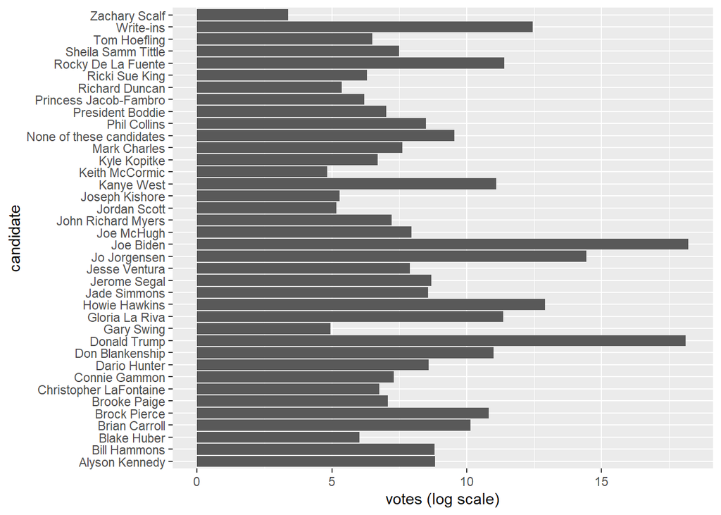

## Winner by County

```
## [1] "County Winner Dataset"
```

| region | county | candidate | party | total_votes | total | pct |
| --- | --- | --- | --- | --- | --- | --- |
| district of columbia | District of Columbia | Joe Biden | DEM | 39041 | 41681 | 93.67 |
| district of columbia | Ward 2 | Joe Biden | DEM | 29078 | 32881 | 88.43 |
| district of columbia | Ward 3 | Joe Biden | DEM | 39397 | 44231 | 89.07 |
| district of columbia | Ward 4 | Joe Biden | DEM | 42489 | 45296 | 93.80 |
| district of columbia | Ward 5 | Joe Biden | DEM | 43320 | 46107 | 93.96 |
| district of columbia | Ward 6 | Joe Biden | DEM | 56719 | 62918 | 90.15 |
| district of columbia | Ward 7 | Joe Biden | DEM | 36382 | 38384 | 94.78 |
| district of columbia | Ward 8 | Joe Biden | DEM | 30897 | 32858 | 94.03 |
| florida | Alachua | Joe Biden | DEM | 89704 | 142604 | 62.90 |
| florida | Baker | Donald Trump | REP | 11911 | 14059 | 84.72 |

[output cut: 2816 more lines]

## Winner by State

```
## [1] "State Winner Dataset"
```

| region | candidate | state.candidate.votes | state.total.votes | pct |
| --- | --- | --- | --- | --- |
| alabama | Donald Trump | 1441168 | 2323304 | 62.03 |
| alaska | Donald Trump | 189892 | 391346 | 48.52 |
| arizona | Joe Biden | 1672143 | 3387326 | 49.36 |
| arkansas | Donald Trump | 760647 | 1219069 | 62.40 |
| california | Joe Biden | 11109764 | 17495906 | 63.50 |
| colorado | Joe Biden | 1804352 | 3256953 | 55.40 |
| connecticut | Joe Biden | 1080680 | 1824280 | 59.24 |
| delaware | Joe Biden | 296268 | 504010 | 58.78 |
| district of columbia | Joe Biden | 317323 | 344356 | 92.15 |
| florida | Donald Trump | 5668731 | 11067456 | 51.22 |

[output cut: 41 more lines]

## US Map colored by State

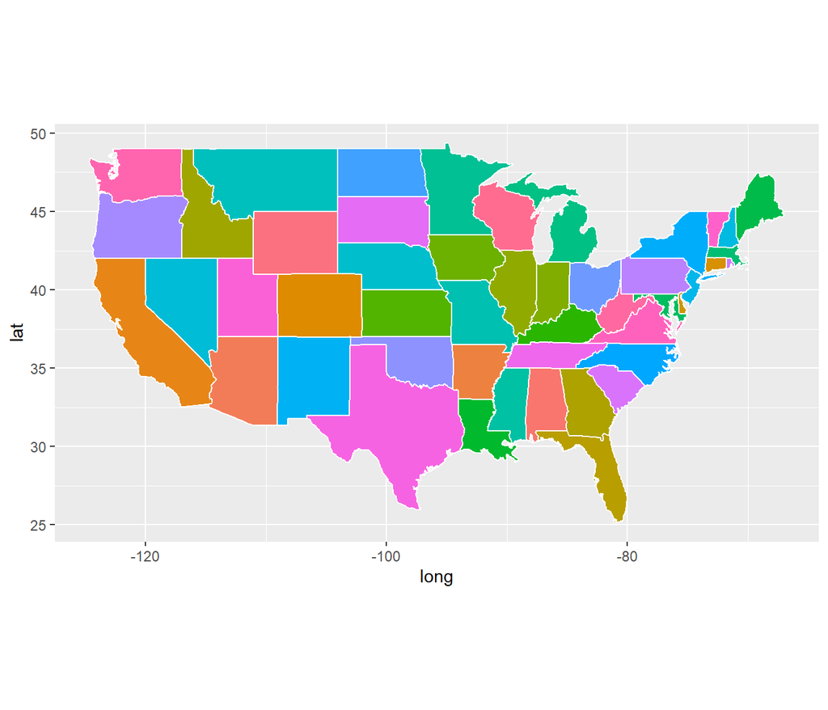

## US Map colored by County

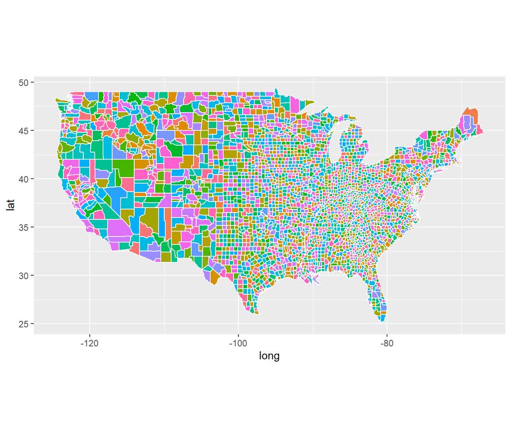

## Winner in each State

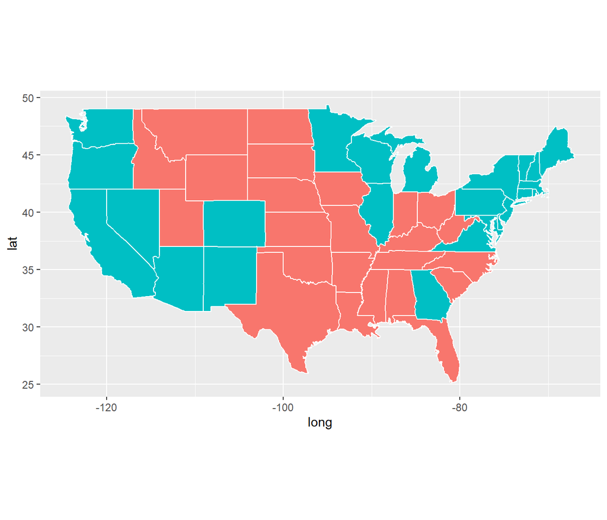

## Winner in each California County

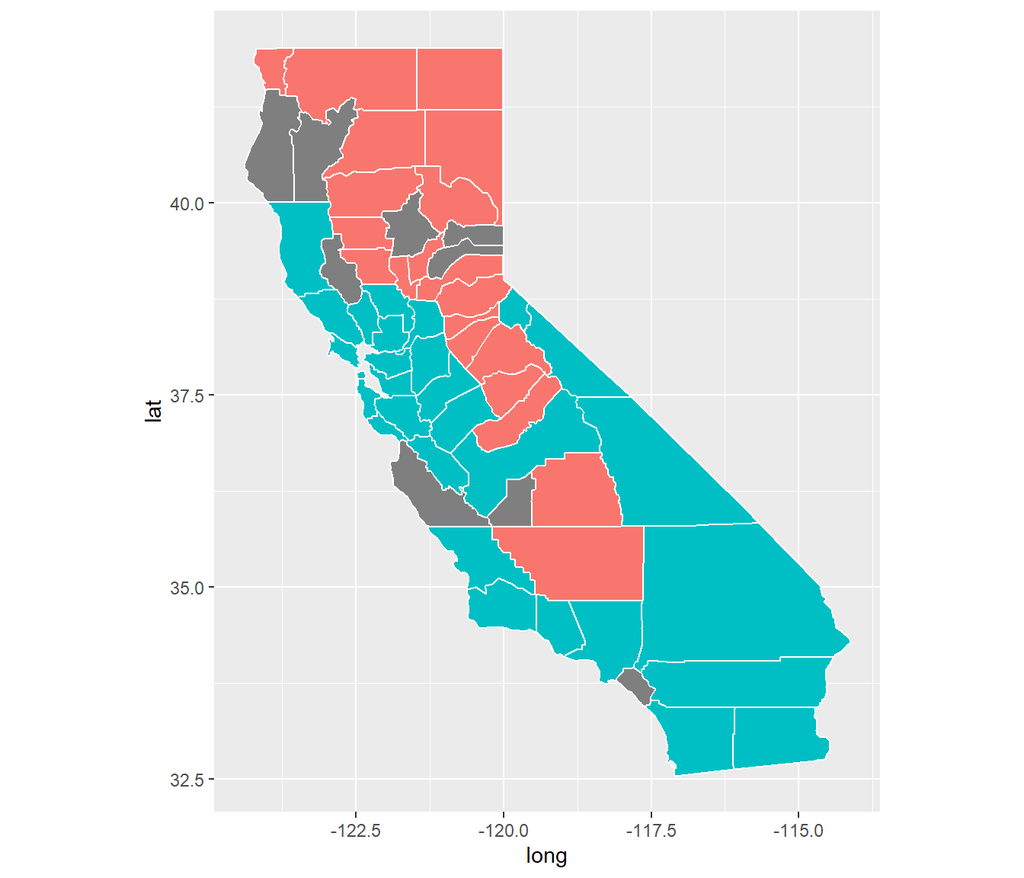

## Cleaning up the Census Data

| CountyId | State | County | TotalPop | Men | White | VotingAgeCitizen | Income | Poverty | ChildPoverty | Professional | Service | Office | Production | Drive | Carpool | Transit | OtherTransp | WorkAtHome | MeanCommute | Employed | PrivateWork | SelfEmployed | FamilyWork | Unemployment | Minority |
| --- | --- | --- | --- | --- | --- | --- | --- | --- | --- | --- | --- | --- | --- | --- | --- | --- | --- | --- | --- | --- | --- | --- | --- | --- | --- |
| 1001 | Alabama | Autauga County | 55036 | 48.87528 | 75.4 | 74.52576 | 55317 | 13.7 | 20.1 | 35.3 | 18.0 | 23.2 | 15.4 | 86.0 | 9.6 | 0.1 | 1.3 | 2.5 | 25.8 | 43.81132 | 74.1 | 5.6 | 0.1 | 5.2 | 22.8 |
| 1003 | Alabama | Baldwin County | 203360 | 48.94129 | 83.1 | 76.40441 | 52562 | 11.8 | 16.1 | 35.7 | 18.2 | 25.6 | 10.8 | 84.7 | 7.6 | 0.1 | 1.1 | 5.6 | 27.0 | 44.02390 | 80.7 | 6.3 | 0.1 | 5.5 | 15.4 |
| 1005 | Alabama | Barbour County | 26201 | 53.34148 | 45.7 | 77.35964 | 33368 | 27.2 | 44.9 | 25.0 | 16.8 | 22.6 | 24.1 | 83.4 | 11.1 | 0.3 | 1.7 | 1.3 | 23.4 | 33.88420 | 74.1 | 6.5 | 0.3 | 12.4 | 52.8 |
| 1007 | Alabama | Bibb County | 22580 | 54.25598 | 74.6 | 78.21966 | 43404 | 15.2 | 26.6 | 24.4 | 17.6 | 19.7 | 22.4 | 86.4 | 9.5 | 0.7 | 1.7 | 1.5 | 30.0 | 36.18689 | 76.0 | 6.3 | 0.3 | 8.2 | 24.8 |
| 1009 | Alabama | Blount County | 57667 | 49.40434 | 87.4 | 73.72154 | 47412 | 15.6 | 25.4 | 28.5 | 12.9 | 23.3 | 19.5 | 86.8 | 10.2 | 0.1 | 0.4 | 2.1 | 35.0 | 37.07493 | 83.9 | 4.0 | 0.1 | 4.9 | 10.9 |

## Racial Minority voter Behavior

```
## [1] "States with more than 40% minority population"
```

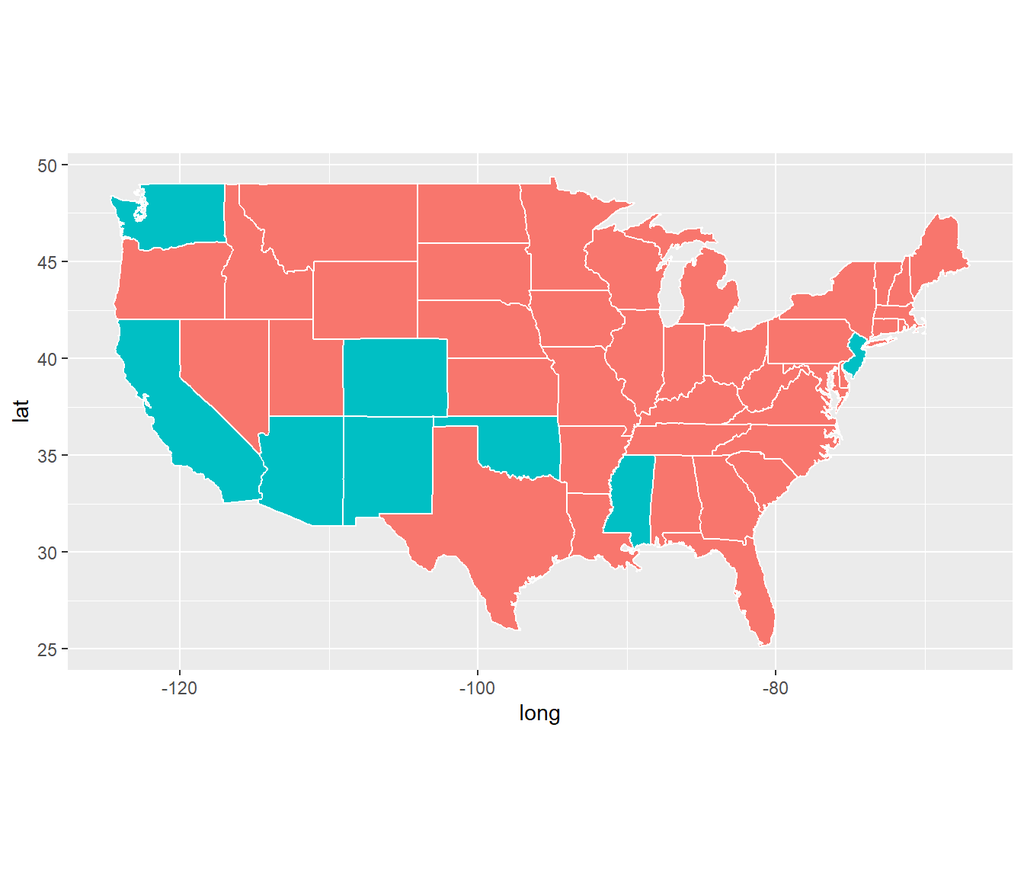

```
## [1] "2020 Election winners"
```

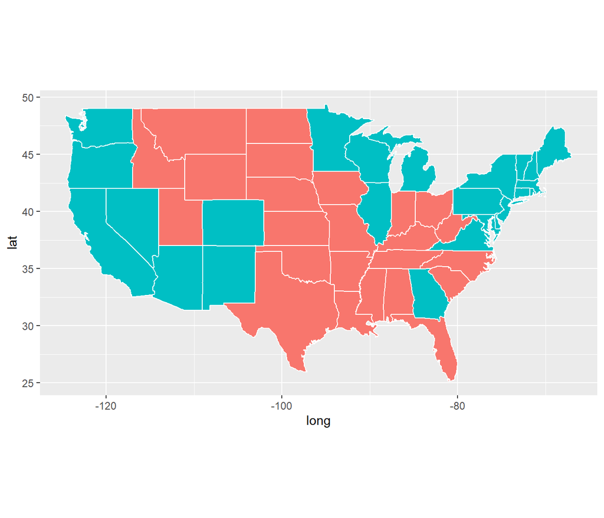

Interestingly, in many states with a high minority population (>40%), Joe biden was the winning candidate

## PCA for Census.clean

```
## [1] "First two Principal Components"
```

```
##             PC1        PC2
## [1,] -0.4043438 -1.1284711
## [2,] -1.0986448 -1.1582214
## [3,]  3.7613801 -0.4212289
## [4,]  1.2111079 -1.3551470
## [5,]  0.1827219 -2.9406990
## [6,]  4.4837389 -0.3316514
```

```
## [1] "Features with largest loadings"
```

```
##      PC1
## [1,] "Poverty"
## [2,] "ChildPoverty"
## [3,] "Employed"
```

Centering must be performed for PCA to work. I scaled my data because some columns were reported as percentage values and others just as raw data. Features with opposite signs are not correlated, meaning they do not interact with one another.

## Plots for PCA 12

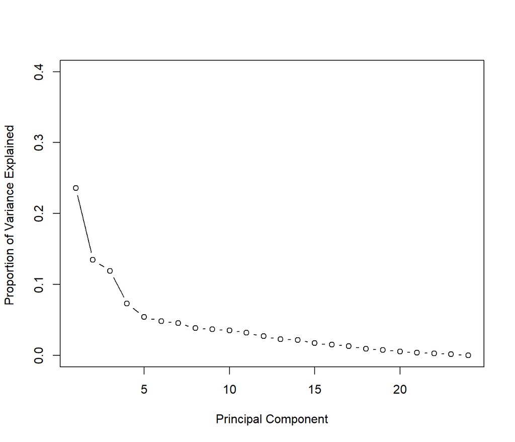

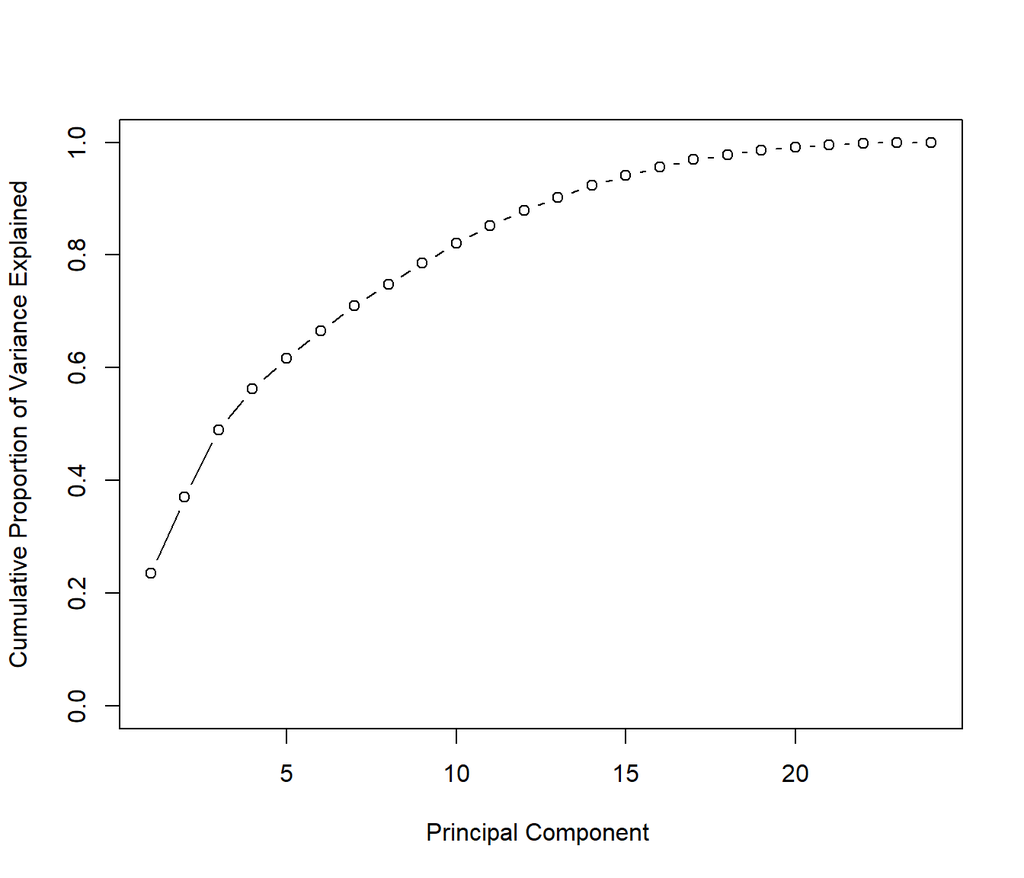

```
## [1] "How many Principal Components to explain 90% of the data?"
```

```
## [1] 0.9019445
```

We need 13 principal components to explain 90% of the variance.

## Clustering

```
## [1] "Clustering"
```

```
## hclust.ct
##    1    2    3    4    5    6    7    8    9   10
## 2750  343    7    1   24   48    1    4   37    4
```

```
## [1] "Clustering with first two principal components"
```

```
## hclust.pc
##    1    2    3    4    5    6    7    8    9   10
## 1680  757   77  196  392   20    1   65   18   13
```

When we include the first two principal components in our hirearchical clustering, our data appear to be more evenly spread out among the clusters. Probably a better model given what we know about the variables in census. ## Check Santa Barbara Cluster

```
## [1] "Index of SB"
```

| CountyId | State | County | TotalPop | Men | White | VotingAgeCitizen | Income | Poverty | ChildPoverty | Professional | Service | Office | Production | Drive | Carpool | Transit | OtherTransp | WorkAtHome | MeanCommute | Employed | PrivateWork | SelfEmployed | FamilyWork | Unemployment | Minority |
| --- | --- | --- | --- | --- | --- | --- | --- | --- | --- | --- | --- | --- | --- | --- | --- | --- | --- | --- | --- | --- | --- | --- | --- | --- | --- |
| 6083 | California | Santa Barbara County | 442996 | 50.10316 | 45.3 | 63.43376 | 68023 | 15.4 | 19.4 | 35.2 | 21.7 | 21 | 8.1 | 68 | 13.6 | 3.2 | 4.8 | 5.8 | 19.4 | 47.80924 | 75.7 | 8.1 | 0.2 | 6.6 | 52.1 |

```
## [1] "What cluster is SB in"
```

```
## [1] 1
```

|  | hclust.ct | CountyId | State | County | TotalPop | Men | White | VotingAgeCitizen | Income | Poverty | ChildPoverty | Professional | Service | Office | Production | Drive | Carpool | Transit | OtherTransp | WorkAtHome | MeanCommute | Employed | PrivateWork | SelfEmployed | FamilyWork | Unemployment | Minority |
| --- | --- | --- | --- | --- | --- | --- | --- | --- | --- | --- | --- | --- | --- | --- | --- | --- | --- | --- | --- | --- | --- | --- | --- | --- | --- | --- | --- |
| 1 | 1 | 1001 | Alabama | Autauga County | 55036 | 48.87528 | 75.4 | 74.52576 | 55317 | 13.7 | 20.1 | 35.3 | 18.0 | 23.2 | 15.4 | 86.0 | 9.6 | 0.1 | 1.3 | 2.5 | 25.8 | 43.81132 | 74.1 | 5.6 | 0.1 | 5.2 | 22.8 |
| 2 | 1 | 1003 | Alabama | Baldwin County | 203360 | 48.94129 | 83.1 | 76.40441 | 52562 | 11.8 | 16.1 | 35.7 | 18.2 | 25.6 | 10.8 | 84.7 | 7.6 | 0.1 | 1.1 | 5.6 | 27.0 | 44.02390 | 80.7 | 6.3 | 0.1 | 5.5 | 15.4 |
| 3 | 1 | 1007 | Alabama | Bibb County | 22580 | 54.25598 | 74.6 | 78.21966 | 43404 | 15.2 | 26.6 | 24.4 | 17.6 | 19.7 | 22.4 | 86.4 | 9.5 | 0.7 | 1.7 | 1.5 | 30.0 | 36.18689 | 76.0 | 6.3 | 0.3 | 8.2 | 24.8 |
| 4 | 1 | 1009 | Alabama | Blount County | 57667 | 49.40434 | 87.4 | 73.72154 | 47412 | 15.6 | 25.4 | 28.5 | 12.9 | 23.3 | 19.5 | 86.8 | 10.2 | 0.1 | 0.4 | 2.1 | 35.0 | 37.07493 | 83.9 | 4.0 | 0.1 | 4.9 | 10.9 |
| 5 | 1 | 1013 | Alabama | Butler County | 20126 | 46.78525 | 52.2 | 76.81109 | 36326 | 24.4 | 34.8 | 26.9 | 17.3 | 18.5 | 25.7 | 83.6 | 12.6 | 0.0 | 0.9 | 2.0 | 23.2 | 38.39312 | 79.1 | 5.3 | 0.3 | 7.6 | 46.2 |
| 6 | 1 | 1015 | Alabama | Calhoun County | 115527 | 48.12122 | 72.7 | 76.50419 | 43686 | 18.6 | 26.6 | 29.0 | 17.5 | 23.7 | 19.4 | 85.0 | 9.2 | 0.2 | 1.1 | 3.2 | 24.8 | 41.02244 | 74.9 | 5.1 | 0.1 | 10.1 | 25.2 |

```
## [1] "Variance of the following variables: Minority, Employed, Poverty, VotingAge"
```

```
## [1] 258.4797
```

```
## [1] 34.34828
```

```
## [1] 31.45831
```

```
## [1] 22.93759
```

To determine whether clustering was performed well we want to examine if clusters represent true subgroups. Meaning observations within each cluster truly share similar attributes. By looking at the overall variance of a few variables within cluster 1, we can get an idea of how well the clustering worked. Furthermore, we can easily compare the calculated variances from the two clustering approaches and draw conclusions.

## Repeat above but with Principal Components

```
## [1] 5
```

|  | hclust.pc | CountyId | State | County | TotalPop | Men | White | VotingAgeCitizen | Income | Poverty | ChildPoverty | Professional | Service | Office | Production | Drive | Carpool | Transit | OtherTransp | WorkAtHome | MeanCommute | Employed | PrivateWork | SelfEmployed | FamilyWork | Unemployment | Minority |
| --- | --- | --- | --- | --- | --- | --- | --- | --- | --- | --- | --- | --- | --- | --- | --- | --- | --- | --- | --- | --- | --- | --- | --- | --- | --- | --- | --- |
| 1 | 5 | 2013 | Alaska | Aleutians East Borough | 3338 | 61.38406 | 15.5 | 61.62373 | 66607 | 16.7 | 20.0 | 16.3 | 13.6 | 9.6 | 45.3 | 26.4 | 5.8 | 0.1 | 3.3 | 5.3 | 5.1 | 72.04913 | 70.9 | 8.1 | 0.1 | 2.4 | 79.4 |
| 2 | 5 | 2016 | Alaska | Aleutians West Census Area | 5784 | 61.18603 | 24.8 | 61.63555 | 85192 | 7.5 | 9.9 | 17.4 | 14.9 | 17.0 | 36.2 | 45.4 | 9.0 | 0.2 | 3.1 | 0.7 | 7.8 | 68.48202 | 79.7 | 3.4 | 0.0 | 1.9 | 70.3 |
| 3 | 5 | 2060 | Alaska | Bristol Bay Borough | 917 | 58.01527 | 50.3 | 75.68157 | 79500 | 7.1 | 11.6 | 30.5 | 18.5 | 21.1 | 14.6 | 58.9 | 16.0 | 0.2 | 4.1 | 3.1 | 9.4 | 55.39804 | 54.3 | 11.0 | 0.0 | 6.8 | 41.0 |
| 4 | 5 | 2068 | Alaska | Denali Borough | 2303 | 50.71646 | 82.7 | 78.46287 | 83295 | 15.5 | 4.8 | 23.1 | 35.2 | 20.9 | 10.8 | 35.0 | 8.8 | 0.5 | 1.1 | 8.2 | 16.1 | 66.39166 | 74.9 | 6.1 | 0.8 | 1.9 | 7.8 |
| 5 | 5 | 2090 | Alaska | Fairbanks North Star Borough | 100031 | 53.95028 | 71.1 | 73.68516 | 76250 | 7.7 | 10.0 | 37.6 | 15.6 | 23.2 | 9.6 | 74.8 | 15.0 | 0.9 | 2.6 | 2.7 | 18.9 | 46.71052 | 65.4 | 4.4 | 0.2 | 8.0 | 21.4 |
| 6 | 5 | 2100 | Alaska | Haines Borough | 2537 | 52.14821 | 79.0 | 76.86244 | 70640 | 8.4 | 20.5 | 36.6 | 18.0 | 21.7 | 12.5 | 56.7 | 10.3 | 0.6 | 9.9 | 13.4 | 7.1 | 56.64170 | 65.7 | 12.4 | 0.8 | 2.7 | 14.4 |

```
## [1] "Variance of the following variables: Minority, Employed, Poverty, VotingAge"
```

```
## [1] 213.0411
```

```
## [1] 29.42531
```

```
## [1] 15.73389
```

```
## [1] 26.61137
```

Overall, we have smaller variances for the variables I selected to investigate. This leads me to be that the cluster Santa Barbara belongs to in the approach that included the first two principal components represents a more accurate subgroup of the data. This approach put Santa Barbara in a more accurate cluster.

## Prepping data for Classification

We need to exclude party because it will have the strongest influence on our response, given that the winning candidate will have the same party preference in every county. Obviously if party=Democrat, candidate=Joe Biden as only one Democrat was running in the primary election.

## Split data into training and test data

## Fit a tree

```
## [1] 16 10  8  7  6  4  3  1
```

```
## [1] 140 140 122 137 149 161 162 227
```

```
## [1] "Tree Size"
```

```
## [1] 8
```

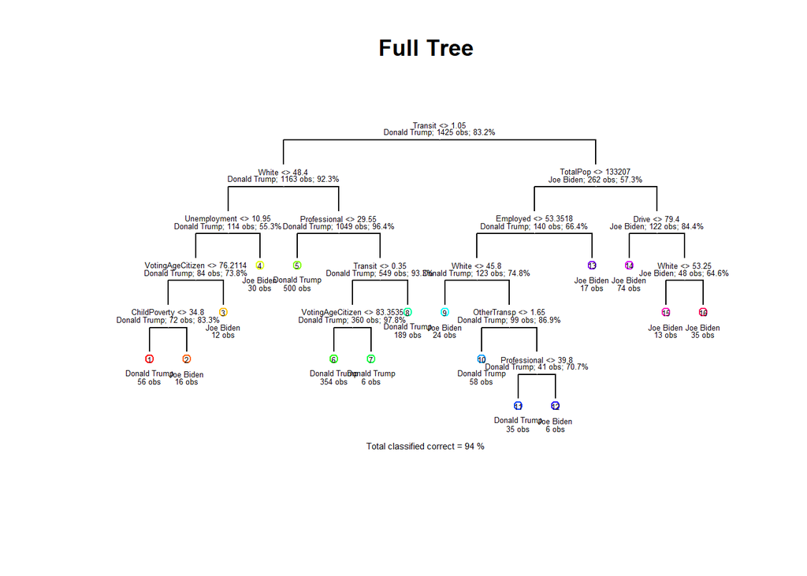

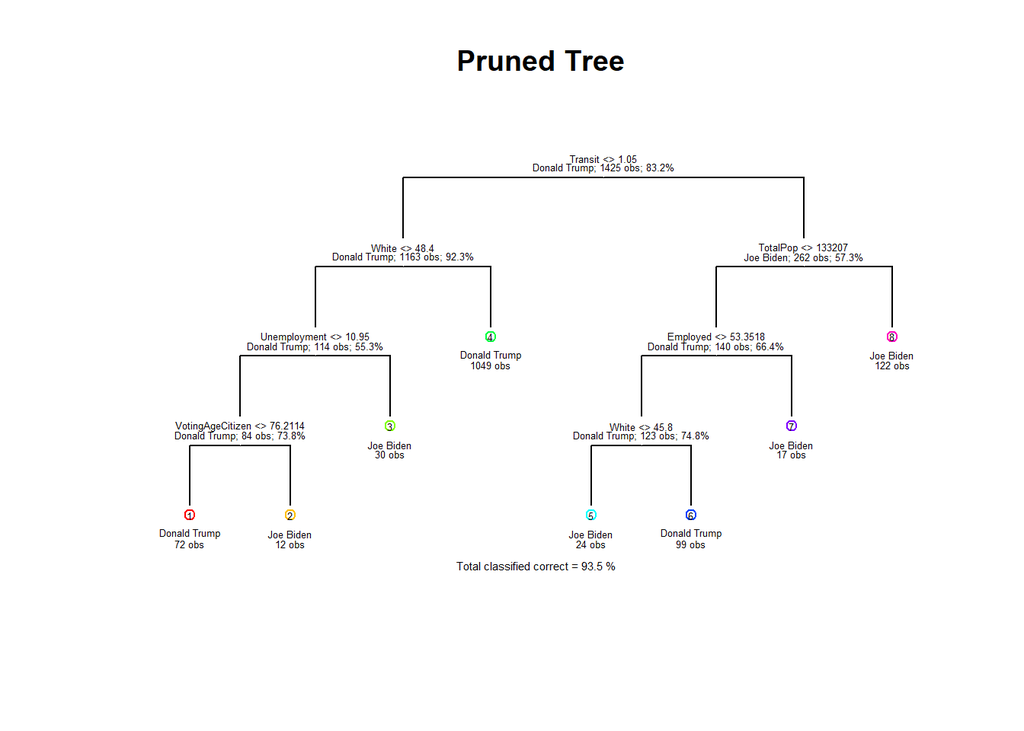

Story time: In the county I live in where more than one of my 100 friends and family use public transportation, I, an employed black citizen under the age of 76 decided to vote for Joe Biden.

## Training and test errors Tree

```
##          train.error test.error
## tree       0.0645614 0.09803922
## logistic          NA         NA
## lasso             NA         NA
```

## Logistic Regression

```
##
## Call:
## glm(formula = candidate ~ ., family = "binomial", data = election.tr)
##
## Coefficients:
##                    Estimate Std. Error z value Pr(>|z|)
## (Intercept)      -2.966e+01  1.194e+01  -2.485 0.012954 *
## TotalPop          5.334e-07  6.694e-07   0.797 0.425609
## Men              -1.125e-02  6.444e-02  -0.175 0.861433
## White            -1.354e-01  8.828e-02  -1.534 0.124951
## VotingAgeCitizen  1.780e-01  3.727e-02   4.777 1.78e-06 ***
## Income           -4.186e-05  2.239e-05  -1.870 0.061544 .
## Poverty          -2.478e-02  5.792e-02  -0.428 0.668698
## ChildPoverty      2.925e-02  3.439e-02   0.850 0.395073
## Professional      3.330e-01  5.676e-02   5.867 4.44e-09 ***
## Service           3.529e-01  6.486e-02   5.441 5.28e-08 ***
## Office            2.103e-01  6.852e-02   3.070 0.002143 **
## Production        1.666e-01  5.828e-02   2.859 0.004244 **
## Drive            -1.866e-01  5.289e-02  -3.528 0.000418 ***
## Carpool          -1.912e-01  7.393e-02  -2.587 0.009686 **
## Transit           3.164e-01  1.210e-01   2.615 0.008919 **
## OtherTransp       5.409e-02  1.145e-01   0.473 0.636536
## WorkAtHome       -8.921e-03  8.673e-02  -0.103 0.918073
## MeanCommute       1.758e-02  3.450e-02   0.510 0.610318
## Employed          2.669e-01  4.627e-02   5.768 8.01e-09 ***
## PrivateWork       7.000e-02  3.004e-02   2.330 0.019797 *
## SelfEmployed     -9.233e-02  6.441e-02  -1.433 0.151746
## FamilyWork       -1.054e+00  5.522e-01  -1.909 0.056248 .
## Unemployment      2.053e-01  6.073e-02   3.380 0.000725 ***
## Minority         -3.270e-04  8.630e-02  -0.004 0.996977
## ---
## Signif. codes:  0 '***' 0.001 '**' 0.01 '*' 0.05 '.' 0.1 ' ' 1
##
## (Dispersion parameter for binomial family taken to be 1)
##
##     Null deviance: 1288.92  on 1424  degrees of freedom
## Residual deviance:  398.13  on 1401  degrees of freedom
## AIC: 446.13
##
## Number of Fisher Scoring iterations: 8
```

```
## [1] "Variable Importance"
```

```
##      Overall
## [1,] "Professional"
## [2,] "Employed"
## [3,] "Service"
## [4,] "VotingAgeCitizen"
## [5,] "Drive"
```

```
##          train.error test.error
## tree      0.06456140 0.09803922
## logistic  0.05473684 0.08123249
## lasso             NA         NA
```

## Problem 17 Lasso

```
## [1] "Optimal lambda parameter"
```

```
## [1] 0.0012
```

```
##  [1] -3.124252e+01  8.438435e-07 -3.722147e-02 -1.349189e-01  2.418539e-01
##  [6]  7.199100e-06  3.238124e-02  2.582030e-01  2.926194e-01  1.437356e-01
## [11]  1.446008e-01 -1.305594e-01 -8.039019e-02  2.219750e-01  1.512541e-01
## [16] -1.242824e-02  2.058738e-01  5.082823e-02 -5.340380e-02 -3.606715e-01
## [21]  1.271032e-01
```

```
## [1] "Comparing our lasso coefs with logarithmic"
```

|  | LassoCoefficients | LogCoefficients | difference |
| --- | --- | --- | --- |
| (Intercept) | -31.24 | -29.66 | 1.58 |
| TotalPop | 0.00 | 0.00 | 0.00 |
| Men | -0.04 | -0.01 | 0.03 |
| White | -0.13 | -0.14 | 0.01 |
| VotingAgeCitizen | 0.24 | 0.18 | 0.06 |
| Income | 0.00 | 0.00 | 0.00 |
| Poverty | 0.03 | -0.02 | 0.05 |
| ChildPoverty | 0.00 | 0.03 | 0.03 |
| Professional | 0.26 | 0.33 | 0.07 |
| Service | 0.29 | 0.35 | 0.06 |

[output cut: 14 more lines]

```
## [1] "Variable Importance"
```

```
##      Overall
## [1,] "FamilyWork"
## [2,] "Service"
## [3,] "Professional"
## [4,] "VotingAgeCitizen"
## [5,] "Transit"
```

```
##          train.error test.error
## tree      0.06456140 0.09803922
## logistic  0.05473684 0.08123249
## lasso     0.26315789 0.22408964
```

Lasso and Log coefficients look relatively similar, sharing a few top 5 influential variables.

## ROC Curves for all 3 models

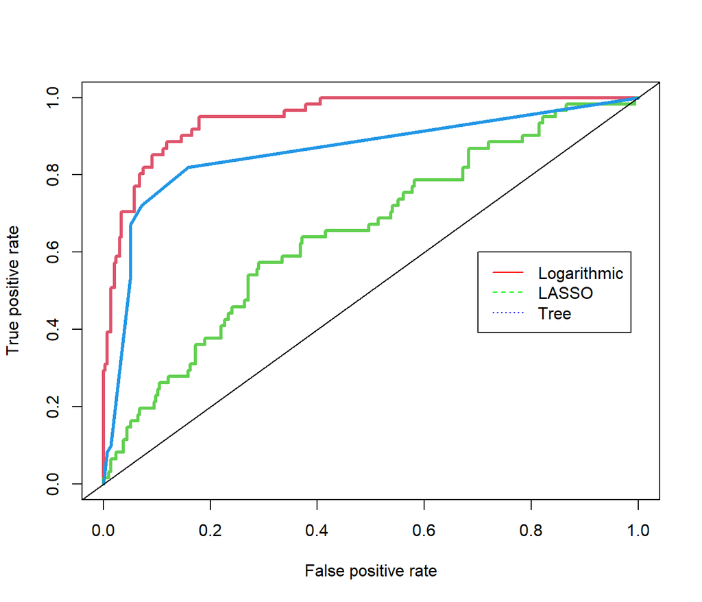

## Preparing for more complex analysis

## Random Forests

```
##                 Length Class  Mode
## call               4   -none- call
## type               1   -none- character
## predicted       1425   factor numeric
## err.rate        1500   -none- numeric
## confusion          6   -none- numeric
## votes           2850   matrix numeric
## oob.times       1425   -none- numeric
## classes            2   -none- character
## importance        92   -none- numeric
## importanceSD      69   -none- numeric
## localImportance    0   -none- NULL
## proximity          0   -none- NULL
## ntree              1   -none- numeric
## mtry               1   -none- numeric
## forest            14   -none- list
## y               1425   factor numeric
## test               0   -none- NULL
## inbag              0   -none- NULL
## terms              3   terms  call
```

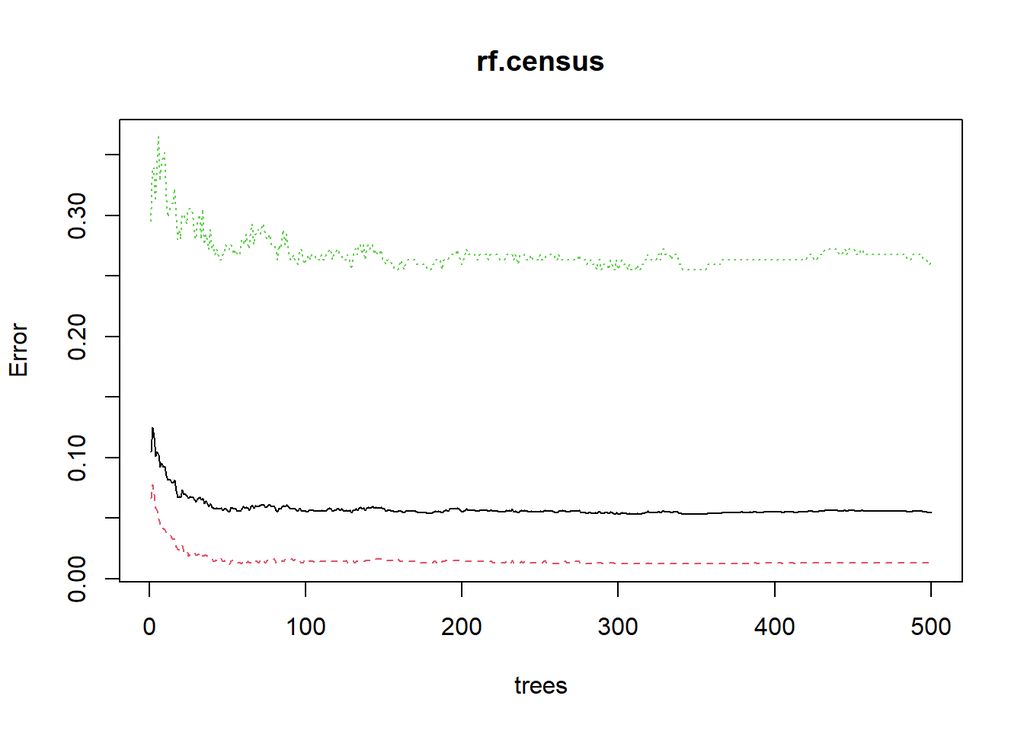

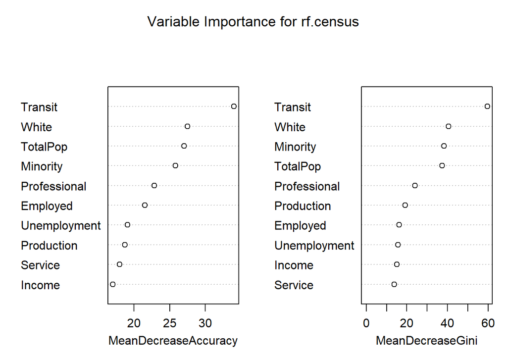

```
##              train.error test.error
## tree          0.06456140 0.09803922
## logistic      0.05473684 0.08123249
## lasso         0.26315789 0.22408964
## randomforest  0.00000000 0.07282913
## boosting              NA         NA
```

It would appear that our random forest model has a very similar variable importance to our original tree model, though does not look much similar to our lasso or logistic model. However, this model seems to have overfit our data (having a training error of 0), so we will see if a boosting model is more accurate.

## Boosting model

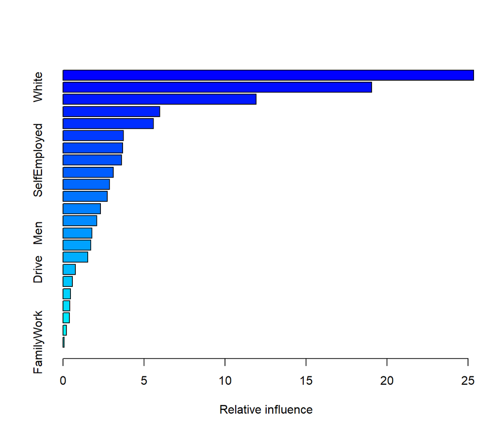

|  | var | rel.inf |
| --- | --- | --- |
| Transit | Transit | 25.3534058 |
| White | White | 19.0605787 |
| TotalPop | TotalPop | 11.9337794 |
| Professional | Professional | 5.9740896 |
| Employed | Employed | 5.5822309 |
| VotingAgeCitizen | VotingAgeCitizen | 3.7393322 |
| Service | Service | 3.6916417 |
| SelfEmployed | SelfEmployed | 3.6054589 |
| Unemployment | Unemployment | 3.1010264 |
| OtherTransp | OtherTransp | 2.8636480 |

[output cut: 13 more lines]

```
## Using 500 trees...
##
## Using 500 trees...
```

```
##              train.error test.error
## tree          0.06456140 0.09803922
## logistic      0.05473684 0.08123249
## lasso         0.26315789 0.22408964
## randomforest  0.00000000 0.07282913
## boosting      0.02245614 0.08683473
```

Our boosting model again looks very similar to our other two tree models, and not much like the lasso or logistic model. The RF, Boosting, and single Tree models share the top 3 most influential variables.

## Linear Regression

```
##
## Call:
## lm(formula = total_votes ~ ., data = election.cl.biden)
##
## Residuals:
##     Min      1Q  Median      3Q     Max
## -247379   -9800    3474   13160  185706
##
## Coefficients:
##                    Estimate Std. Error t value Pr(>|t|)
## (Intercept)      -1.621e+05  2.466e+05  -0.657  0.51145
## TotalPop          2.938e-01  4.071e-03  72.159  < 2e-16 ***
## Men              -1.021e+02  1.607e+03  -0.064  0.94940
## White            -1.088e+03  1.344e+03  -0.809  0.41914
## VotingAgeCitizen  1.932e+03  7.279e+02   2.654  0.00841 **
## Income            1.703e-01  4.128e-01   0.413  0.68023
## Poverty           4.592e+02  1.197e+03   0.384  0.70158
## ChildPoverty      1.676e+02  7.972e+02   0.210  0.83363
## Professional      6.518e+02  1.298e+03   0.502  0.61598
## Service          -1.106e+03  1.602e+03  -0.690  0.49077
## Office           -2.167e+03  1.675e+03  -1.293  0.19695
## Production       -3.101e+02  1.599e+03  -0.194  0.84635
## Drive             4.724e+02  1.133e+03   0.417  0.67700
## Carpool           1.195e+03  1.778e+03   0.672  0.50211
## Transit           4.003e+02  1.505e+03   0.266  0.79043
## OtherTransp       3.499e+03  2.602e+03   1.345  0.17978
## WorkAtHome        2.204e+03  2.003e+03   1.100  0.27216
## MeanCommute      -1.034e+02  8.480e+02  -0.122  0.90307
## Employed          1.021e+03  9.219e+02   1.108  0.26886
## PrivateWork       4.764e+02  5.571e+02   0.855  0.39315
## SelfEmployed     -1.188e+03  1.683e+03  -0.706  0.48079
## FamilyWork        1.050e+03  9.298e+03   0.113  0.91020
## Unemployment     -2.086e+01  1.383e+03  -0.015  0.98797
## Minority         -5.858e+02  1.377e+03  -0.425  0.67094
## ---
## Signif. codes:  0 '***' 0.001 '**' 0.01 '*' 0.05 '.' 0.1 ' ' 1
##
## Residual standard error: 48700 on 276 degrees of freedom
## Multiple R-squared:  0.9659, Adjusted R-squared:  0.963
## F-statistic: 339.5 on 23 and 276 DF,  p-value: < 2.2e-16
```

```
##
## Call:
## lm(formula = total_votes ~ ., data = election.cl.trump)
##
## Residuals:
##     Min      1Q  Median      3Q     Max
## -127562   -1866    -319    1332   50411
##
## Coefficients:
##                    Estimate Std. Error t value Pr(>|t|)
## (Intercept)      -5.395e+04  1.579e+04  -3.416 0.000652 ***
## TotalPop          2.668e-01  2.306e-03 115.659  < 2e-16 ***
## Men              -1.832e+02  8.232e+01  -2.225 0.026221 *
## White             1.883e+02  1.078e+02   1.747 0.080826 .
## VotingAgeCitizen -1.183e+01  5.258e+01  -0.225 0.822001
## Income            8.014e-02  3.406e-02   2.353 0.018746 *
## Poverty          -1.764e+02  9.025e+01  -1.955 0.050797 .
## ChildPoverty      2.866e+01  4.790e+01   0.598 0.549735
## Professional      2.521e+02  6.699e+01   3.763 0.000174 ***
## Service           2.221e+02  7.297e+01   3.044 0.002380 **
## Office            2.479e+02  7.699e+01   3.220 0.001310 **
## Production       -1.427e+01  6.005e+01  -0.238 0.812182
## Drive             2.192e+02  7.871e+01   2.784 0.005435 **
## Carpool           1.718e+02  9.934e+01   1.729 0.083934 .
## Transit          -6.799e+01  2.214e+02  -0.307 0.758767
## OtherTransp       2.920e+02  1.870e+02   1.562 0.118593
## WorkAtHome        3.796e+02  1.230e+02   3.085 0.002076 **
## MeanCommute       9.542e+01  4.105e+01   2.325 0.020226 *
## Employed         -2.514e+02  5.441e+01  -4.620 4.17e-06 ***
## PrivateWork       2.343e+02  4.312e+01   5.434 6.44e-08 ***
## SelfEmployed      4.543e+01  7.495e+01   0.606 0.544515
## FamilyWork        4.325e+02  4.137e+02   1.045 0.296089
## Unemployment     -4.983e+01  8.864e+01  -0.562 0.574086
## Minority          1.315e+02  1.079e+02   1.218 0.223441
## ---
## Signif. codes:  0 '***' 0.001 '**' 0.01 '*' 0.05 '.' 0.1 ' ' 1
##
## Residual standard error: 6612 on 1458 degrees of freedom
## Multiple R-squared:  0.9403, Adjusted R-squared:  0.9394
## F-statistic: 998.5 on 23 and 1458 DF,  p-value: < 2.2e-16
```

```
##      Overall
## [1,] "TotalPop"
## [2,] "VotingAgeCitizen"
## [3,] "OtherTransp"
## [4,] "Office"
## [5,] "Employed"
```

```
##      Overall
## [1,] "TotalPop"
## [2,] "PrivateWork"
## [3,] "Employed"
## [4,] "Professional"
## [5,] "Office"
```

These models have some shared characteristics to our classification models. I first noticed that total population is the predictor with the highest influence in both the model for trump and the model for Biden In all three our tree models (single,random forest, and boosting), total population also falls into the top three most important predictors. Another variable with a lot of influence in our Biden model was VotingAgeCitizen, which also had a lot of influence in our lasso model. Interestingly, transit is not a highly inflential variable in our linear models, but was highly important in all of our classification models except our logistic regression model.

## Discuss insights

I prefer our classification methods over our regression method. I believe the issue we are trying to tackle falls much more into the classification setting than the regression one. The prediction we are trying to make is: “Which candidate is going to win in which state.” When we set total votes to be our response in a linear setting, we are simply looking at how many votes that candidate got, without comparing it to the other candidate. Here, totalpop is the predictor with the most influence, simply because a state with a higher population will have more votes in the election in general, not just for a specific candidate. I believe our classification methods that compare both candidates at once do a better job of answering the question we are trying to ask.

White and Minority predictors are self explanatory in this case. Our trees modeled that higher White percentage generally meant more votes for Trump. This is consistent with the 2016 model we see in the Washington post.

Total population also has some correlation to demographics. A higher population would in most cases correlate to a large city, which I know to be more racially diverse than rural areas. There is generally a higher percentage of educated citizens near urban areas.

Percentage professionalism is certainly correlated with the education rates of that county, another predictor deemed important by the Washington post.